# Oneil Cruz Pitch Sequencing

# Left vs. Right handed pitchers

Now, we’re going to see if there’s a difference between Cruz vs. right- and left-handed pitching. We’re going to compare his general pitch sequencing to his pitch sequencing on at-bats ending in a slider strike out.

## LHPs

First, we’re looking at LHPs, the side that I believe he is worse against.

### Percentage of pitch type by count on at-bats ending in slider strikeouts

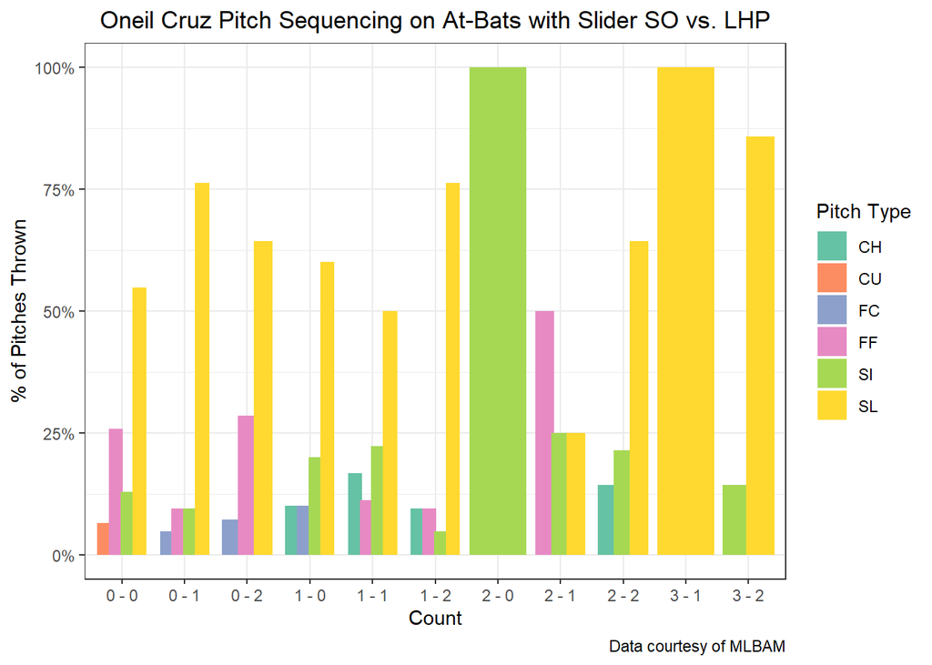

### Frequency of pitch type by count on at-bats ending in slider strikeouts

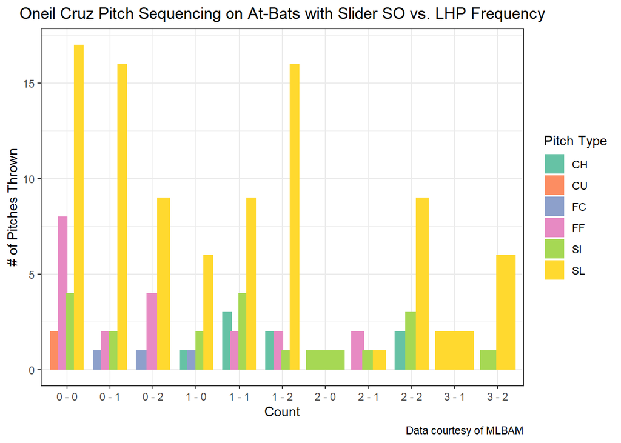

Lefties are throwing sliders the most in every count except 2 - 0 and 2 - 1 where the end result was an Oneil Cruz strikeout on a slider. Over 50% of the first pitches were a slider. The second most thrown pitch was a 4-seam fastball at a quarter of first pitches. In 0 - 1 counts, left-handed pitchers are throwing sliders over 75% of the time. In 1 - 0 counts, sliders are thrown in approximately 60% of at-bats. In 1 - 1 counts, slider is the pitch 50% of the time Typically, off-speed pitches are used later in the count; however, left-handed pitchers are setting him up with sliders. Additionally, LHPs are throwing sinkers the second most in six counts. Sinkers break towards a batter like a 2-seam fastball; however, there is significant downward drop or “sinking” movement. Sliders have the opposite lateral movement of a sinker; however, they drop, but not as much (depends on the grip, arm action, pitcher, etc.). For most batters, it is easier to bat against a pitcher of the opposite handedness because it is easier to see pitches break. Oneil Cruz may struggle to see pitches breaking when batting against lefties.